# Tugas Pertemuan 4

Ayunda Rasyid Khairunnisa

2025-09-23

# Tugas Pertemuan 4 MPDW

Nama : Ayunda Rasyid Khairunnisa NIM : G14012131048

## White Noise

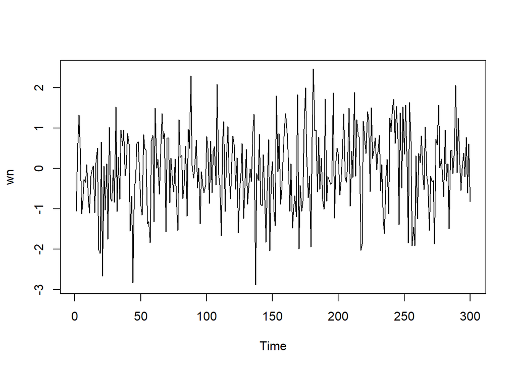

```r
set.seed(1048)
wn <- rnorm(300)
ts.plot(wn)
```

## Proses MA

### Pembangkitan Proses MA(2)

Bangkitkan model MA(2) dengan $\theta_1 = 0.4$ dan $\theta_2 = 0.6$ sebanyak 300 observasi (manual dan dengan arima.sim)

### Manual

```r
set.seed(1048)
wn <- rnorm(300)
ma2 <- numeric(300)
```

Nilai selanjutnya dapat dicari melalui loop. Bentuk loop dapat dilihat dari rumus MA(2) yang hendak dibangkitkan:
$$y_t = e_t + 0.4 e_{t-1} + 0.6
e_{t-2}$$

```r
for(i in 3:300){
   ma2[i-2] <- wn[i] + 0.4  * wn[i - 1] + 0.6 * wn[i-2]
}
ma2
```

```
##   [1]  0.84487319  1.26935901 -0.13233979 -0.94650040 -1.27302282 -0.93257038
##   [7] -0.20948698 -0.84375297 -1.31986306 -1.03172899 -0.77220254 -0.06164654
##  [13] -1.09349057 -0.26429649 -0.09777742 -1.72804606 -2.60376052 -1.39132346
##  [19] -3.66664759 -0.61960280 -2.61273370 -0.26645449 -2.32703949  0.38658598
##  [25] -1.39004774 -0.49767521 -0.80366432 -1.34193156  1.16489039 -0.96783248
##  [31]  0.76369215 -1.29136639  0.81456487  0.48236602  1.74372597  0.53083383
##  [37]  0.56713354  0.78510851  0.99243764 -0.78850278 -0.94376719 -4.03032049
##  [43] -1.95219410 -2.20412161  0.22077134  0.69496167  0.52951702 -0.57554525
##  [49] -1.58292862 -0.17992596  0.13559175  1.15519072 -0.89162673 -1.59054022
##  [55] -3.18805627 -0.84797971 -0.01836624 -0.58586163  1.45007397 -0.19047103
##  [61]  1.12671518 -0.54419029  0.24144397  1.11449173  1.48855336  1.97024328
##  [67] -0.78458242  0.63827211  0.10884769 -0.10113063  0.36160259 -0.72291173
##  [73] -0.55483175 -0.18132028 -1.01880324 -1.69429360  0.13842276 -0.16186610
##  [79]  1.15849591 -0.44877536 -0.42478165 -0.02484026 -1.15445539  0.82793828
##  [85]  0.16930391  3.07296855  1.28319888  1.16989388  0.03098812  0.59488650
```

[output cut: 35 more lines]

### Arima.sim

```r
ma2_A <- arima.sim(list(order=c(0,0,2), ma=c(0.4, 0.6)), n=300)
ma2_A
```

```
## Time Series:
## Start = 1
## End = 300
## Frequency = 1
##   [1] -0.654760286  0.584232533 -0.843465608  0.793665788 -0.179745188
##   [6] -0.420497674  0.050383449 -0.631524500  0.833763043 -1.142244812
##  [11] -0.512785384 -0.093329966  0.100807782  1.627311414  0.144337376
##  [16]  0.928665753 -0.765490129 -0.910002438 -0.465157515  0.675058289
##  [21]  2.228165964  3.327062688  0.795592654  0.707203999  0.015762012
##  [26] -1.469503934 -1.576354105 -0.610266929 -0.532997803 -1.877611986
##  [31] -1.545910298 -1.682869586 -0.478404807  1.346179141 -0.441874836
##  [36] -0.182231542 -2.311417340 -0.687300328 -1.958771882 -0.634974816
##  [41] -0.740788584 -0.931863393 -2.367890068 -0.484201807 -1.347172748
##  [46]  0.545726581 -0.744367403  0.508648379  1.482674082  1.026593176
##  [51]  0.671482869 -2.324113936  0.003127763 -0.784605105  1.022954208
```

[output cut: 49 more lines]

## Karakteristik MA(2)

Untuk melihat karakteristik dari MA(2), digunakan data dari pembangkitan MA(2) secara manual. ### Plot Time Series

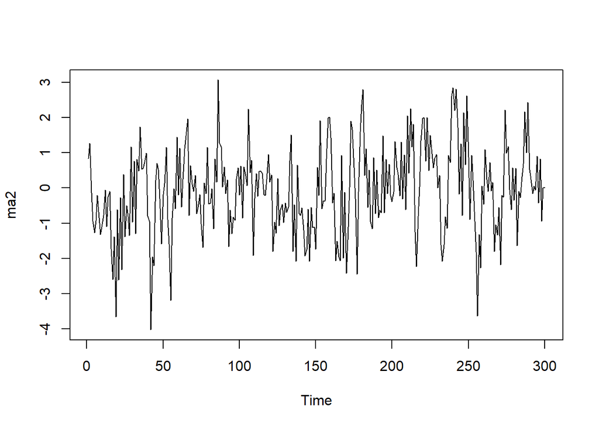

```r
ts.plot(ma2)
```

Berdasarkan plot time series, terlihat bahwa data MA(2) yang dibangkitkan stasioner dalam rataan

### Plot ACF

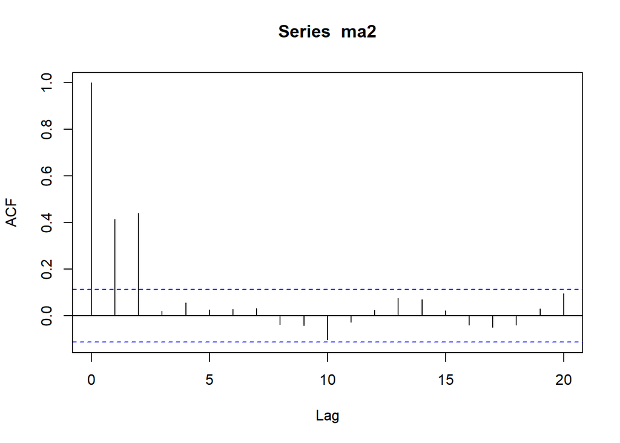

```r
acf(ma2,lag.max = 20)
```

Berdasarkan plot ACF tersebut, terlihat bahwa plot ACF cuts off di lag kedua.

### Plot PACF

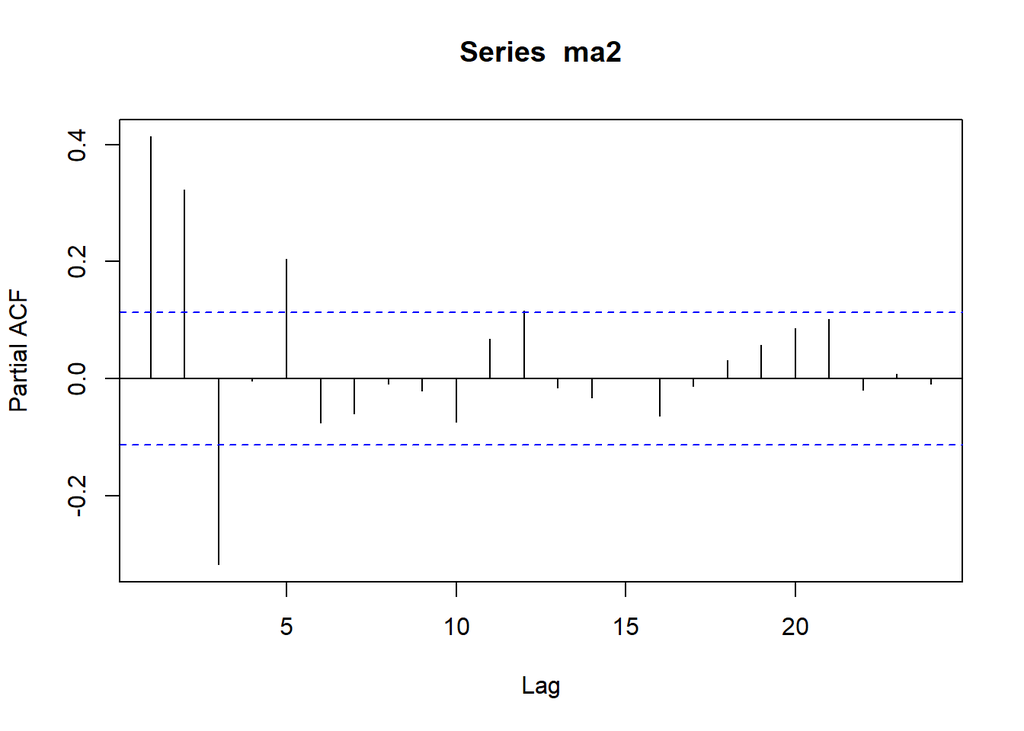

```r
pacf(ma2)
```

Berdasarkan plot PACF tersebut, terlihat bahwa plot PACF cenderung tails off dan membentuk gelombang sinus.

### Plot EACF

```r
TSA::eacf(ma2)
```

```
## AR/MA
##   0 1 2 3 4 5 6 7 8 9 10 11 12 13
## 0 x x o o o o o o o o o  o  o  o
## 1 x x x o o o o o o o o  o  o  o
## 2 x x x x o o o o o o o  o  o  o
## 3 o x x o o o o o o o o  o  o  o
## 4 o x x o o x o o o o o  o  o  o
## 5 x x x x x o o o o o o  o  o  o
## 6 x x o o x o o x o o o  o  o  o
## 7 x x o o x o o x o o o  o  o  o
```

Berdasarkan pola segitiga nol pada plot EACF, terlihat bahawa segitiga nol berada pada ordo AR(0) dan ordo MA(2) sehingga mengarah pada ARMA(0,2) atau proses MA(2). Hal ini konsisten dengan data simulasi yang memang dibangkitkan dari proses MA.

## Scatterplot Antar Lag

### Korelasi Antara Yt dengan Yt-1

```r
#Yt
yt_ma2 <- ma2[-1]
yt_ma2
```

```
##   [1]  1.26935901 -0.13233979 -0.94650040 -1.27302282 -0.93257038 -0.20948698
##   [7] -0.84375297 -1.31986306 -1.03172899 -0.77220254 -0.06164654 -1.09349057
##  [13] -0.26429649 -0.09777742 -1.72804606 -2.60376052 -1.39132346 -3.66664759
##  [19] -0.61960280 -2.61273370 -0.26645449 -2.32703949  0.38658598 -1.39004774
##  [25] -0.49767521 -0.80366432 -1.34193156  1.16489039 -0.96783248  0.76369215
##  [31] -1.29136639  0.81456487  0.48236602  1.74372597  0.53083383  0.56713354
##  [37]  0.78510851  0.99243764 -0.78850278 -0.94376719 -4.03032049 -1.95219410
##  [43] -2.20412161  0.22077134  0.69496167  0.52951702 -0.57554525 -1.58292862
##  [49] -0.17992596  0.13559175  1.15519072 -0.89162673 -1.59054022 -3.18805627
##  [55] -0.84797971 -0.01836624 -0.58586163  1.45007397 -0.19047103  1.12671518
##  [61] -0.54419029  0.24144397  1.11449173  1.48855336  1.97024328 -0.78458242
##  [67]  0.63827211  0.10884769 -0.10113063  0.36160259 -0.72291173 -0.55483175
##  [73] -0.18132028 -1.01880324 -1.69429360  0.13842276 -0.16186610  1.15849591
##  [79] -0.44877536 -0.42478165 -0.02484026 -1.15445539  0.82793828  0.16930391
##  [85]  3.07296855  1.28319888  1.16989388  0.03098812  0.59488650 -0.15762106
```

[output cut: 35 more lines]

```r
#Yt-1
yt_1_ma2 <- ma2[-300]
yt_1_ma2
```

```
##   [1]  0.84487319  1.26935901 -0.13233979 -0.94650040 -1.27302282 -0.93257038
##   [7] -0.20948698 -0.84375297 -1.31986306 -1.03172899 -0.77220254 -0.06164654
##  [13] -1.09349057 -0.26429649 -0.09777742 -1.72804606 -2.60376052 -1.39132346
##  [19] -3.66664759 -0.61960280 -2.61273370 -0.26645449 -2.32703949  0.38658598
##  [25] -1.39004774 -0.49767521 -0.80366432 -1.34193156  1.16489039 -0.96783248
##  [31]  0.76369215 -1.29136639  0.81456487  0.48236602  1.74372597  0.53083383
##  [37]  0.56713354  0.78510851  0.99243764 -0.78850278 -0.94376719 -4.03032049
##  [43] -1.95219410 -2.20412161  0.22077134  0.69496167  0.52951702 -0.57554525
##  [49] -1.58292862 -0.17992596  0.13559175  1.15519072 -0.89162673 -1.59054022
##  [55] -3.18805627 -0.84797971 -0.01836624 -0.58586163  1.45007397 -0.19047103
##  [61]  1.12671518 -0.54419029  0.24144397  1.11449173  1.48855336  1.97024328
##  [67] -0.78458242  0.63827211  0.10884769 -0.10113063  0.36160259 -0.72291173
##  [73] -0.55483175 -0.18132028 -1.01880324 -1.69429360  0.13842276 -0.16186610
##  [79]  1.15849591 -0.44877536 -0.42478165 -0.02484026 -1.15445539  0.82793828
##  [85]  0.16930391  3.07296855  1.28319888  1.16989388  0.03098812  0.59488650
```

[output cut: 35 more lines]

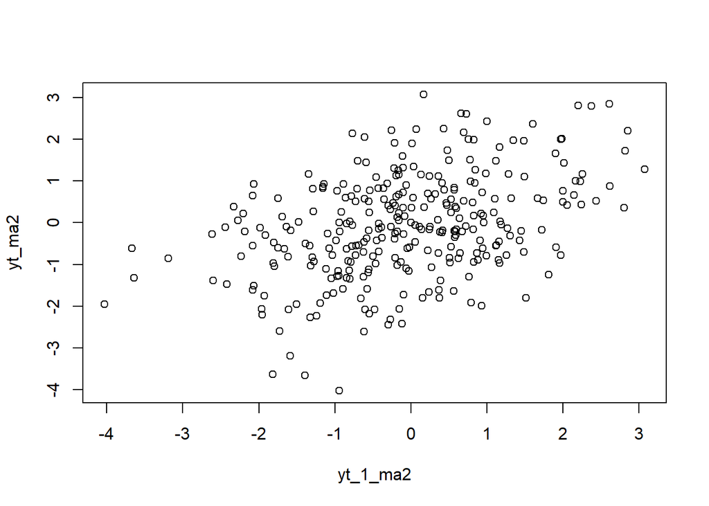

```r
plot(y=yt_ma2,x=yt_1_ma2)
```

```r
cor(yt_ma2,yt_1_ma2)
```

```
## [1] 0.4138556
```

Berdasarkan scatterplot tersebut, terlihat bahwa terdapat hubungan positif antara $Y_t$ dengan $Y_t-1$. Hal in sesuai dengan teori yang ada:

Korelasi antara $Y_t$ dengan $Y_t-1$ dari hasil simulasi mendekati perhitungan teoritis yaitu:
$$\rho_1 = \frac{\gamma_1}{\gamma_0}
= \frac{\theta_1 + \theta_1 \theta_2}{1 + \theta_1^2 + \theta_2^2}
= \frac{0.4 + (0.4)(0.6)}{1 + 0.4^2 + 0.6^2}
= 0.421$$

Korelasi antara $Y_t$ dengan $Y_t-2$

```r
#Yt
yt_ma_2 <- ma2[-c(1,2)]
yt_ma_2
```

```
##   [1] -0.13233979 -0.94650040 -1.27302282 -0.93257038 -0.20948698 -0.84375297
##   [7] -1.31986306 -1.03172899 -0.77220254 -0.06164654 -1.09349057 -0.26429649
##  [13] -0.09777742 -1.72804606 -2.60376052 -1.39132346 -3.66664759 -0.61960280
##  [19] -2.61273370 -0.26645449 -2.32703949  0.38658598 -1.39004774 -0.49767521
##  [25] -0.80366432 -1.34193156  1.16489039 -0.96783248  0.76369215 -1.29136639
##  [31]  0.81456487  0.48236602  1.74372597  0.53083383  0.56713354  0.78510851
##  [37]  0.99243764 -0.78850278 -0.94376719 -4.03032049 -1.95219410 -2.20412161
##  [43]  0.22077134  0.69496167  0.52951702 -0.57554525 -1.58292862 -0.17992596
##  [49]  0.13559175  1.15519072 -0.89162673 -1.59054022 -3.18805627 -0.84797971
##  [55] -0.01836624 -0.58586163  1.45007397 -0.19047103  1.12671518 -0.54419029
##  [61]  0.24144397  1.11449173  1.48855336  1.97024328 -0.78458242  0.63827211
##  [67]  0.10884769 -0.10113063  0.36160259 -0.72291173 -0.55483175 -0.18132028
##  [73] -1.01880324 -1.69429360  0.13842276 -0.16186610  1.15849591 -0.44877536
##  [79] -0.42478165 -0.02484026 -1.15445539  0.82793828  0.16930391  3.07296855
##  [85]  1.28319888  1.16989388  0.03098812  0.59488650 -0.15762106  0.23751592
```

[output cut: 35 more lines]

```r
#Yt-2
yt_2_ma2 <- ma2[-c(299,300)]
yt_2_ma2
```

```
##   [1]  0.84487319  1.26935901 -0.13233979 -0.94650040 -1.27302282 -0.93257038
##   [7] -0.20948698 -0.84375297 -1.31986306 -1.03172899 -0.77220254 -0.06164654
##  [13] -1.09349057 -0.26429649 -0.09777742 -1.72804606 -2.60376052 -1.39132346
##  [19] -3.66664759 -0.61960280 -2.61273370 -0.26645449 -2.32703949  0.38658598
##  [25] -1.39004774 -0.49767521 -0.80366432 -1.34193156  1.16489039 -0.96783248
##  [31]  0.76369215 -1.29136639  0.81456487  0.48236602  1.74372597  0.53083383
##  [37]  0.56713354  0.78510851  0.99243764 -0.78850278 -0.94376719 -4.03032049
##  [43] -1.95219410 -2.20412161  0.22077134  0.69496167  0.52951702 -0.57554525
##  [49] -1.58292862 -0.17992596  0.13559175  1.15519072 -0.89162673 -1.59054022
##  [55] -3.18805627 -0.84797971 -0.01836624 -0.58586163  1.45007397 -0.19047103
##  [61]  1.12671518 -0.54419029  0.24144397  1.11449173  1.48855336  1.97024328
##  [67] -0.78458242  0.63827211  0.10884769 -0.10113063  0.36160259 -0.72291173
##  [73] -0.55483175 -0.18132028 -1.01880324 -1.69429360  0.13842276 -0.16186610
##  [79]  1.15849591 -0.44877536 -0.42478165 -0.02484026 -1.15445539  0.82793828
##  [85]  0.16930391  3.07296855  1.28319888  1.16989388  0.03098812  0.59488650
```

[output cut: 35 more lines]

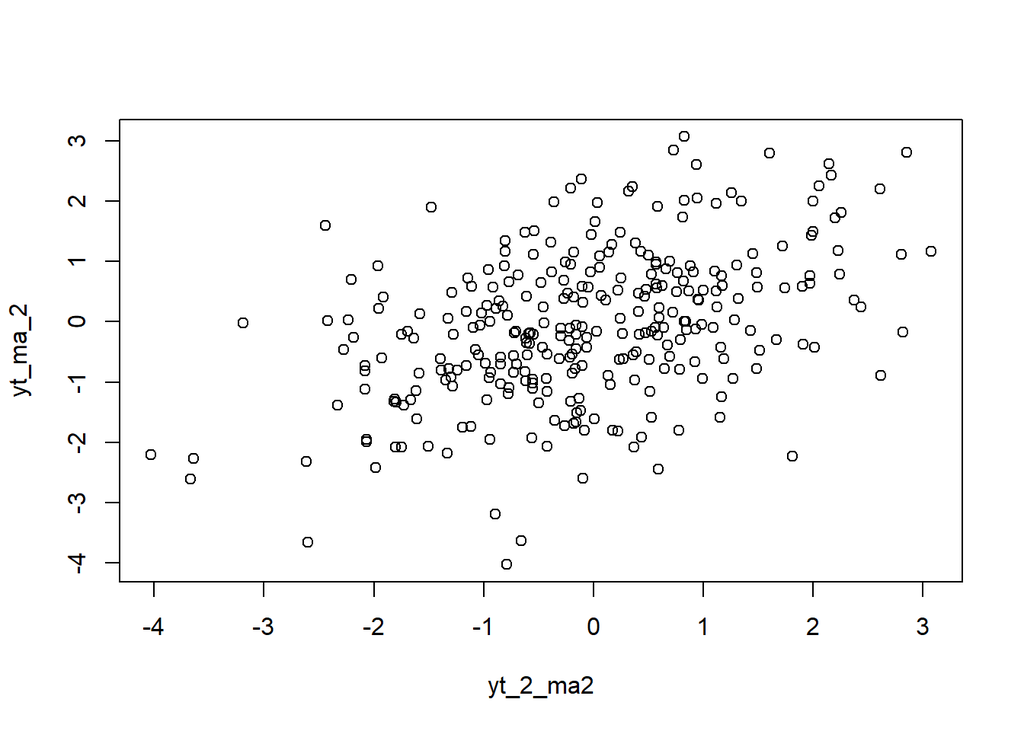

```r
plot(y=yt_ma_2,x=yt_2_ma2)
```

```r
cor(yt_ma_2,yt_2_ma2)
```

```
## [1] 0.4404125
```

Berdasarkan scattelerplot tersebut, terlihat bahwa terdapat hubungan positif antara $Y_t$ dengan $Y_t-2$. Hal ini sesuai dengan teori yang ada:

Korelasi antara $Y_t$ dengan $Y_t-2$ dari hasil simulasi mendekati perhitungan teoritis yaitu:
$$\rho_2 = \frac{\gamma_2}{\gamma_0}
= \frac{\theta_2}{1 + \theta_1^2 + \theta_2^2}
= \frac{0.6}{1 + 0.4^2 + 0.6^2}
= 0.395$$
### Korelasi antara Yt dengan Tt-3

```r
#Yt
yt_ma2_3 <- ma2[-c(1,2,3)]
yt_ma2_3
```

```
##   [1] -0.94650040 -1.27302282 -0.93257038 -0.20948698 -0.84375297 -1.31986306
##   [7] -1.03172899 -0.77220254 -0.06164654 -1.09349057 -0.26429649 -0.09777742
##  [13] -1.72804606 -2.60376052 -1.39132346 -3.66664759 -0.61960280 -2.61273370
##  [19] -0.26645449 -2.32703949  0.38658598 -1.39004774 -0.49767521 -0.80366432
##  [25] -1.34193156  1.16489039 -0.96783248  0.76369215 -1.29136639  0.81456487
##  [31]  0.48236602  1.74372597  0.53083383  0.56713354  0.78510851  0.99243764
##  [37] -0.78850278 -0.94376719 -4.03032049 -1.95219410 -2.20412161  0.22077134
##  [43]  0.69496167  0.52951702 -0.57554525 -1.58292862 -0.17992596  0.13559175
##  [49]  1.15519072 -0.89162673 -1.59054022 -3.18805627 -0.84797971 -0.01836624
##  [55] -0.58586163  1.45007397 -0.19047103  1.12671518 -0.54419029  0.24144397
##  [61]  1.11449173  1.48855336  1.97024328 -0.78458242  0.63827211  0.10884769
##  [67] -0.10113063  0.36160259 -0.72291173 -0.55483175 -0.18132028 -1.01880324
##  [73] -1.69429360  0.13842276 -0.16186610  1.15849591 -0.44877536 -0.42478165
##  [79] -0.02484026 -1.15445539  0.82793828  0.16930391  3.07296855  1.28319888
##  [85]  1.16989388  0.03098812  0.59488650 -0.15762106  0.23751592 -1.66411327
```

[output cut: 35 more lines]

```r
#Yt-3
yt_3_ma2 <- ma2[-c(298, 299,300)]
yt_3_ma2
```

```
##   [1]  0.84487319  1.26935901 -0.13233979 -0.94650040 -1.27302282 -0.93257038
##   [7] -0.20948698 -0.84375297 -1.31986306 -1.03172899 -0.77220254 -0.06164654
##  [13] -1.09349057 -0.26429649 -0.09777742 -1.72804606 -2.60376052 -1.39132346
##  [19] -3.66664759 -0.61960280 -2.61273370 -0.26645449 -2.32703949  0.38658598
##  [25] -1.39004774 -0.49767521 -0.80366432 -1.34193156  1.16489039 -0.96783248
##  [31]  0.76369215 -1.29136639  0.81456487  0.48236602  1.74372597  0.53083383
##  [37]  0.56713354  0.78510851  0.99243764 -0.78850278 -0.94376719 -4.03032049
##  [43] -1.95219410 -2.20412161  0.22077134  0.69496167  0.52951702 -0.57554525
##  [49] -1.58292862 -0.17992596  0.13559175  1.15519072 -0.89162673 -1.59054022
##  [55] -3.18805627 -0.84797971 -0.01836624 -0.58586163  1.45007397 -0.19047103
##  [61]  1.12671518 -0.54419029  0.24144397  1.11449173  1.48855336  1.97024328
##  [67] -0.78458242  0.63827211  0.10884769 -0.10113063  0.36160259 -0.72291173
##  [73] -0.55483175 -0.18132028 -1.01880324 -1.69429360  0.13842276 -0.16186610
##  [79]  1.15849591 -0.44877536 -0.42478165 -0.02484026 -1.15445539  0.82793828
##  [85]  0.16930391  3.07296855  1.28319888  1.16989388  0.03098812  0.59488650
```

[output cut: 35 more lines]

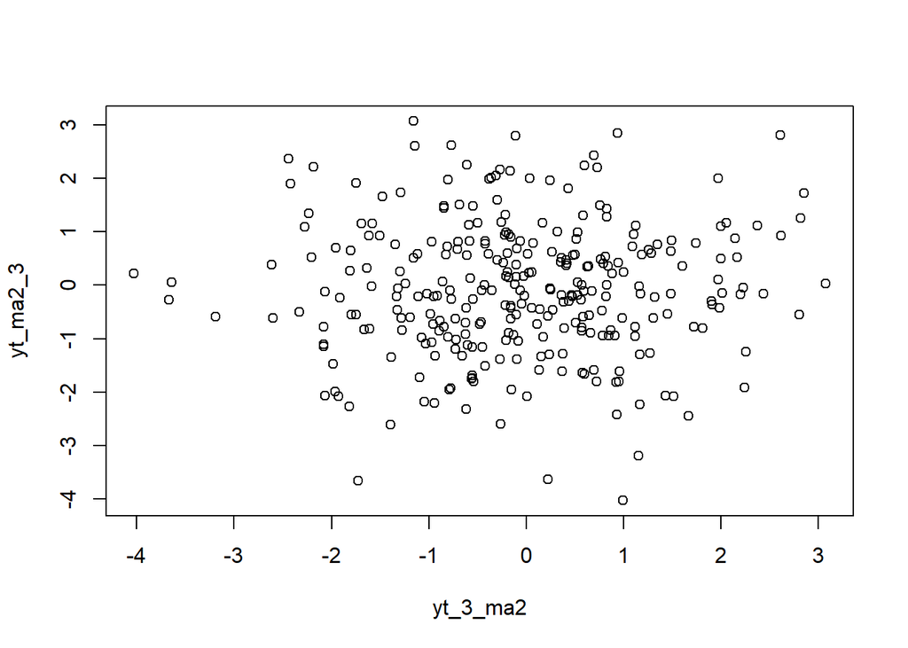

```r
plot(y=yt_ma2_3,x=yt_3_ma2)
```

```r
cor(yt_ma2_3,yt_3_ma2)
```

```
## [1] 0.02078494
```

Berdasarkan scatterplot tersebut, terlihat bahwa cenderung tidak terdapat hubungan antara $Y_t$ dengan $Y_t−3$. Korelasi antara $Y_t$ dengan $Y_t−3$ hasil simulasi mendekati teori yang ada yaitu 0.

## Proses AR(2)

### Pembangkitan Proses AR(2)

Dibangkitkan proses AR(2) dengan $\phi_1 = 0.5$ dan $\phi_2 = 0.2$ sebanyak 300 observasi.

```r
set.seed(1048)
ar2 <- wn[1:2]
```

### Manual

```r
for (i in 3:300) {
  ar2[i] <- wn[i] + 0.5 * ar2[i-1] + 0.2 * ar2[i-2]
}
ar2
```

```
##   [1] -1.059048109  0.401223164  1.308614749  1.235252001 -0.245158506
##   [6] -0.672646267 -0.664826212 -0.809453745 -0.442491715 -1.059462904
##  [11] -1.724682580 -1.257585963 -1.008719527 -0.693516231 -1.645942866
##  [16] -0.824411266 -0.235612486 -2.295405288 -3.296967974 -1.450401298
##  [21] -4.052821635 -2.263101166 -2.975268143 -1.825481445 -3.260851050
##  [26] -0.976576865 -1.886250346 -1.949166042 -1.383732191 -1.924435927
##  [31]  0.282160096 -1.314447443 -0.321518133 -1.184340187  0.294803662
##  [36]  0.468803840  1.243014176  0.531279053  0.585180512  1.265972601
##  [41]  1.353046537 -0.620270562 -0.725112299 -3.312703206 -2.211779194
##  [46] -2.112734031 -0.893986918 -0.209890696 -0.380927102 -1.164902936
##  [51] -1.810270390 -0.297911592 -0.020519701  0.385029964 -1.179458642
##  [56] -1.829038959 -2.991219415 -1.183284550 -0.375020657 -1.742854840
##  [61]  0.542198160 -0.072182238  0.303770009 -0.502484126  0.168076089
##  [66]  1.338566894  1.434303270  1.849531051 -0.357665419  0.938262631
##  [71]  1.149145228 -0.087837765  0.436609718 -0.112416499 -0.548876266
```

[output cut: 45 more lines]

### arima.sim

```r
ar2_a<- arima.sim(list(order=c(2,0,0), ar=c(0.5, 0.2)), n=300)
ar2_a
```

```
## Time Series:
## Start = 1
## End = 300
## Frequency = 1
##   [1] -0.977161812 -1.886696278 -1.949505998 -1.383991355 -1.924633501
##   [6]  0.282009476 -1.314562267 -0.321605670 -1.184406920  0.294752788
##  [11]  0.468765057  1.242984610  0.531256513  0.585163328  1.265959502
##  [16]  1.353036551 -0.620278175 -0.725118103 -3.312707631 -2.211782567
##  [21] -2.112736602 -0.893988878 -0.209892190 -0.380928241 -1.164903805
##  [26] -1.810271052 -0.297912097 -0.020520085  0.385029670 -1.179458866
##  [31] -1.829039129 -2.991219545 -1.183284649 -0.375020733 -1.742854897
##  [36]  0.542198116 -0.072182271  0.303769983 -0.502484146  0.168076074
##  [41]  1.338566883  1.434303261  1.849531044 -0.357665424  0.938262628
##  [46]  1.149145225 -0.087837767  0.436609717 -0.112416501 -0.548876267
##  [51] -0.058353445 -0.905188431 -1.995204714  0.031900512 -0.110609127
```

[output cut: 49 more lines]

## Karakteristik AR(2)

untuk melihat karakteristik dari AR(2), digunakan data dari pembangkitan RA(2) dengan arima.sim.

### Plot Time Series

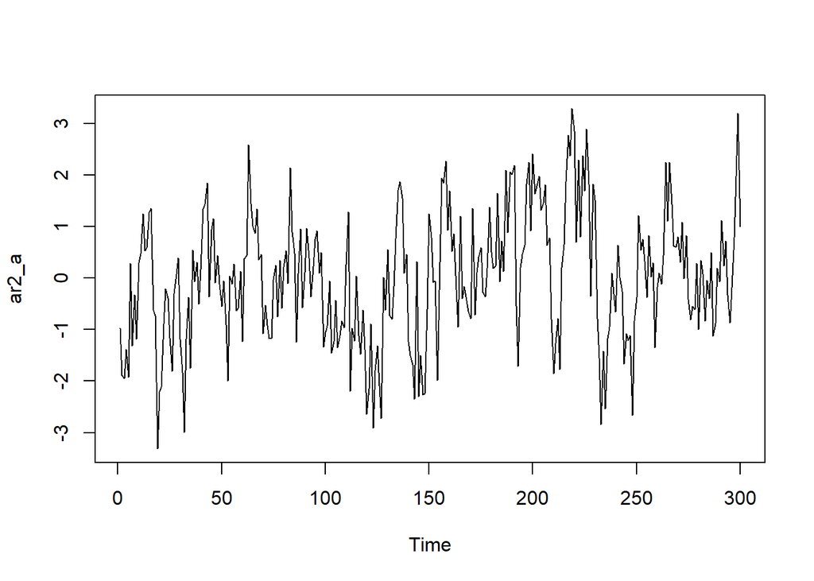

```r
ts.plot(ar2_a)
```

Berdasarkan plot time series tersebut terlihat bahwa data cenderung stasioner pada rataan.

### Plot ACF

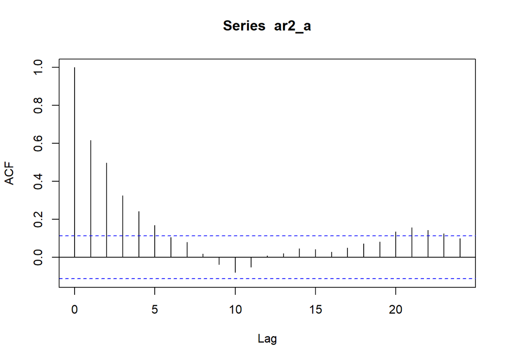

```r
acf(ar2_a)
```

Berdasarkan plot ACF tersebut terlihat bahwa plot ACF cenderung tails off dan cenderung membentuk pola grafik sinus.

### Plot PACF

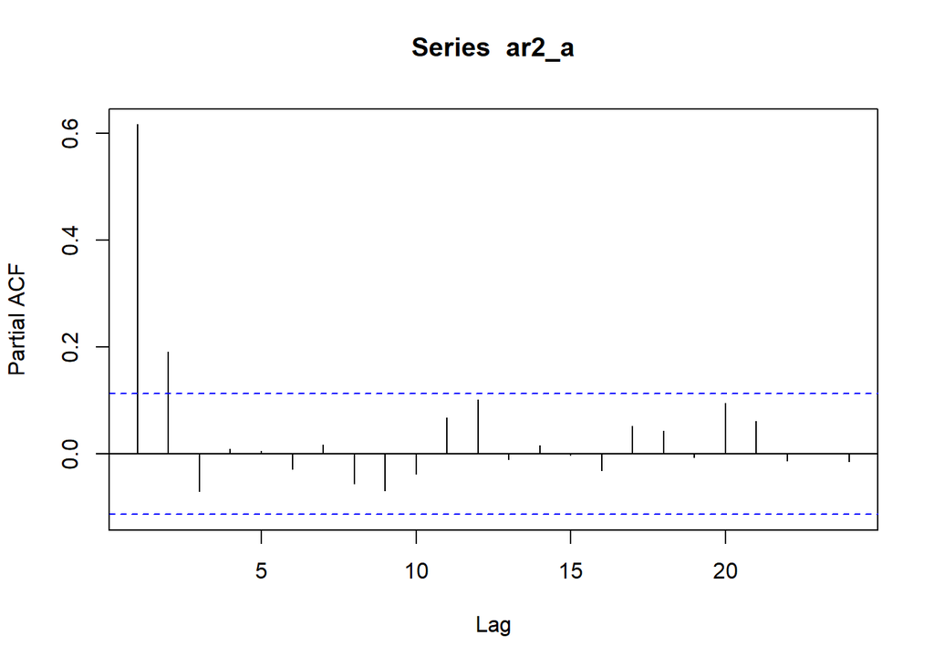

```r
pacf(ar2_a)
```

Berdasarkan plot PACF tersebut, terlihat bahwa plot PACF cuts off pada lag kedua, sejalan dengan teori yang ada.

### Plot EACF

```r
TSA::eacf(ar2_a)
```

```
## AR/MA
##   0 1 2 3 4 5 6 7 8 9 10 11 12 13
## 0 x x x x x o o o o o o  o  o  o
## 1 x x o o o o o o o o o  o  o  o
## 2 x o o o o o o o o o o  o  o  o
## 3 o o o o o o o o o o o  o  o  o
## 4 x o o o o o o o o o o  o  o  o
## 5 x x x o o o o o o o o  o  o  o
## 6 x x x o o o o o o o o  o  o  o
## 7 x x x o x o o o o o o  o  o  o
```

## Scattlerplot Antar Lag

### Korelasi antara Yt dengan Yt-1

```r
#Yt
yt_ar2 <- ar2_a[-1]
yt_ar2
```

```
##   [1] -1.886696278 -1.949505998 -1.383991355 -1.924633501  0.282009476
##   [6] -1.314562267 -0.321605670 -1.184406920  0.294752788  0.468765057
##  [11]  1.242984610  0.531256513  0.585163328  1.265959502  1.353036551
##  [16] -0.620278175 -0.725118103 -3.312707631 -2.211782567 -2.112736602
##  [21] -0.893988878 -0.209892190 -0.380928241 -1.164903805 -1.810271052
##  [26] -0.297912097 -0.020520085  0.385029670 -1.179458866 -1.829039129
##  [31] -2.991219545 -1.183284649 -0.375020733 -1.742854897  0.542198116
##  [36] -0.072182271  0.303769983 -0.502484146  0.168076074  1.338566883
##  [41]  1.434303261  1.849531044 -0.357665424  0.938262628  1.149145225
##  [46] -0.087837767  0.436609717 -0.112416501 -0.548876267 -0.058353445
##  [51] -0.905188431 -1.995204714  0.031900512 -0.110609127  0.274254492
##  [56] -0.626530453 -0.580488997  0.133360542 -1.230192573  0.382477438
##  [61]  0.434608498  2.588464004  1.452841903  1.008533791  0.877042462
##  [66]  1.343579589  0.358912271  0.458991421 -1.074191243 -0.524448706
##  [71] -0.918243660 -1.167037774 -1.174915812 -0.033099965  0.249188471
```

[output cut: 45 more lines]

```r
#Yt-1
yt_1_ar2 <- ar2_a[-300]
yt_1_ar2
```

```
##   [1] -0.977161812 -1.886696278 -1.949505998 -1.383991355 -1.924633501
##   [6]  0.282009476 -1.314562267 -0.321605670 -1.184406920  0.294752788
##  [11]  0.468765057  1.242984610  0.531256513  0.585163328  1.265959502
##  [16]  1.353036551 -0.620278175 -0.725118103 -3.312707631 -2.211782567
##  [21] -2.112736602 -0.893988878 -0.209892190 -0.380928241 -1.164903805
##  [26] -1.810271052 -0.297912097 -0.020520085  0.385029670 -1.179458866
##  [31] -1.829039129 -2.991219545 -1.183284649 -0.375020733 -1.742854897
##  [36]  0.542198116 -0.072182271  0.303769983 -0.502484146  0.168076074
##  [41]  1.338566883  1.434303261  1.849531044 -0.357665424  0.938262628
##  [46]  1.149145225 -0.087837767  0.436609717 -0.112416501 -0.548876267
##  [51] -0.058353445 -0.905188431 -1.995204714  0.031900512 -0.110609127
##  [56]  0.274254492 -0.626530453 -0.580488997  0.133360542 -1.230192573
##  [61]  0.382477438  0.434608498  2.588464004  1.452841903  1.008533791
##  [66]  0.877042462  1.343579589  0.358912271  0.458991421 -1.074191243
##  [71] -0.524448706 -0.918243660 -1.167037774 -1.174915812 -0.033099965
```

[output cut: 45 more lines]

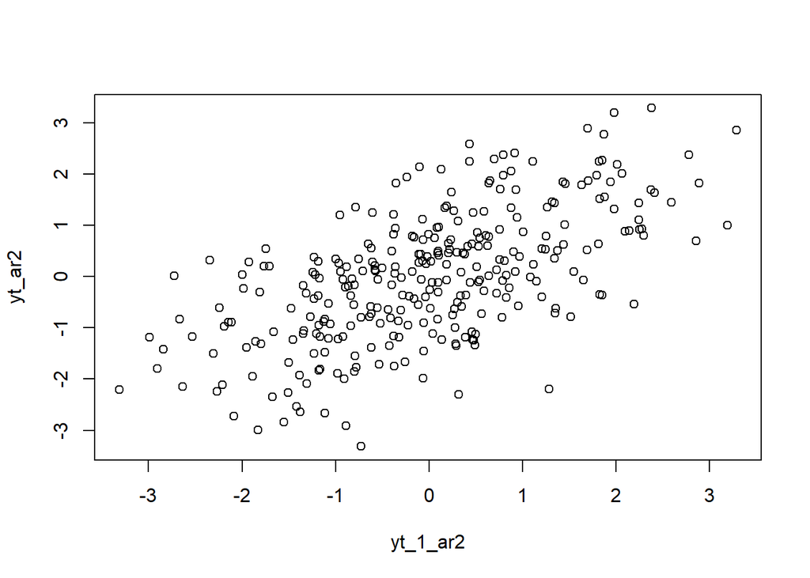

```r
plot(y=yt_ar2,x=yt_1_ar2)
```

Berdasarkan scatterplot tersebut, terlihat bahwa terdapat hubungan positif antara $Y_t$ dengan $Y_t−1$. Hal ini sesuai dengan teori yang ada.

```r
cor(yt_ar2,yt_1_ar2)
```

```
## [1] 0.6180258
```

Korelasi antara $Y_t$ dengan $Y_t−1$ dari hasil simulasi mendekati perhitungan teoritis yaitu:

$$\rho_1 = \frac{\phi_1}{1 - \phi_2}
= \frac{0.5}{1 - 0.2}
= 0.625$$
### Korelasi antara Yt dengan Yt-2

```r
#Yt
yt_ar_2 <- ar2_a[-c(1,2)]
yt_ar_2
```

```
##   [1] -1.949505998 -1.383991355 -1.924633501  0.282009476 -1.314562267
##   [6] -0.321605670 -1.184406920  0.294752788  0.468765057  1.242984610
##  [11]  0.531256513  0.585163328  1.265959502  1.353036551 -0.620278175
##  [16] -0.725118103 -3.312707631 -2.211782567 -2.112736602 -0.893988878
##  [21] -0.209892190 -0.380928241 -1.164903805 -1.810271052 -0.297912097
##  [26] -0.020520085  0.385029670 -1.179458866 -1.829039129 -2.991219545
##  [31] -1.183284649 -0.375020733 -1.742854897  0.542198116 -0.072182271
##  [36]  0.303769983 -0.502484146  0.168076074  1.338566883  1.434303261
##  [41]  1.849531044 -0.357665424  0.938262628  1.149145225 -0.087837767
##  [46]  0.436609717 -0.112416501 -0.548876267 -0.058353445 -0.905188431
##  [51] -1.995204714  0.031900512 -0.110609127  0.274254492 -0.626530453
##  [56] -0.580488997  0.133360542 -1.230192573  0.382477438  0.434608498
##  [61]  2.588464004  1.452841903  1.008533791  0.877042462  1.343579589
##  [66]  0.358912271  0.458991421 -1.074191243 -0.524448706 -0.918243660
##  [71] -1.167037774 -1.174915812 -0.033099965  0.249188471 -0.750849770
```

[output cut: 45 more lines]

```r
#Yt-2
yt_2_ar2 <- ar2_a[-c(299,300)]
yt_2_ar2
```

```
##   [1] -0.977161812 -1.886696278 -1.949505998 -1.383991355 -1.924633501
##   [6]  0.282009476 -1.314562267 -0.321605670 -1.184406920  0.294752788
##  [11]  0.468765057  1.242984610  0.531256513  0.585163328  1.265959502
##  [16]  1.353036551 -0.620278175 -0.725118103 -3.312707631 -2.211782567
##  [21] -2.112736602 -0.893988878 -0.209892190 -0.380928241 -1.164903805
##  [26] -1.810271052 -0.297912097 -0.020520085  0.385029670 -1.179458866
##  [31] -1.829039129 -2.991219545 -1.183284649 -0.375020733 -1.742854897
##  [36]  0.542198116 -0.072182271  0.303769983 -0.502484146  0.168076074
##  [41]  1.338566883  1.434303261  1.849531044 -0.357665424  0.938262628
##  [46]  1.149145225 -0.087837767  0.436609717 -0.112416501 -0.548876267
##  [51] -0.058353445 -0.905188431 -1.995204714  0.031900512 -0.110609127
##  [56]  0.274254492 -0.626530453 -0.580488997  0.133360542 -1.230192573
##  [61]  0.382477438  0.434608498  2.588464004  1.452841903  1.008533791
##  [66]  0.877042462  1.343579589  0.358912271  0.458991421 -1.074191243
##  [71] -0.524448706 -0.918243660 -1.167037774 -1.174915812 -0.033099965
```

[output cut: 45 more lines]

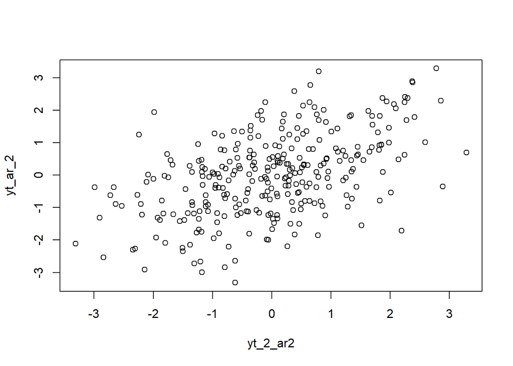

```r
plot(y=yt_ar_2,x=yt_2_ar2)
```

Berdasarkan scatterplot tersebut, terlihat bahwa terdapat hubungan positif antara $Y_t$ dengan $Y_t−2$. Hal ini sesuai dengan teori yang ada

```r
cor(yt_ar_2,yt_2_ar2)
```

```
## [1] 0.5069158
```

### Korelasi antara Yt dengan Yt-3

```r
#Yt
yt_ar3 <- ar2_a[-c(1,2,3)]
yt_ar3
```

```
##   [1] -1.383991355 -1.924633501  0.282009476 -1.314562267 -0.321605670
##   [6] -1.184406920  0.294752788  0.468765057  1.242984610  0.531256513
##  [11]  0.585163328  1.265959502  1.353036551 -0.620278175 -0.725118103
##  [16] -3.312707631 -2.211782567 -2.112736602 -0.893988878 -0.209892190
##  [21] -0.380928241 -1.164903805 -1.810271052 -0.297912097 -0.020520085
##  [26]  0.385029670 -1.179458866 -1.829039129 -2.991219545 -1.183284649
##  [31] -0.375020733 -1.742854897  0.542198116 -0.072182271  0.303769983
##  [36] -0.502484146  0.168076074  1.338566883  1.434303261  1.849531044
##  [41] -0.357665424  0.938262628  1.149145225 -0.087837767  0.436609717
##  [46] -0.112416501 -0.548876267 -0.058353445 -0.905188431 -1.995204714
##  [51]  0.031900512 -0.110609127  0.274254492 -0.626530453 -0.580488997
##  [56]  0.133360542 -1.230192573  0.382477438  0.434608498  2.588464004
##  [61]  1.452841903  1.008533791  0.877042462  1.343579589  0.358912271
##  [66]  0.458991421 -1.074191243 -0.524448706 -0.918243660 -1.167037774
##  [71] -1.174915812 -0.033099965  0.249188471 -0.750849770  0.345451009
```

[output cut: 45 more lines]

```r
#Yt-3
yt_3_ar2 <- ar2_a[-c(298,299,300)]
yt_3_ar2
```

```
##   [1] -0.977161812 -1.886696278 -1.949505998 -1.383991355 -1.924633501
##   [6]  0.282009476 -1.314562267 -0.321605670 -1.184406920  0.294752788
##  [11]  0.468765057  1.242984610  0.531256513  0.585163328  1.265959502
##  [16]  1.353036551 -0.620278175 -0.725118103 -3.312707631 -2.211782567
##  [21] -2.112736602 -0.893988878 -0.209892190 -0.380928241 -1.164903805
##  [26] -1.810271052 -0.297912097 -0.020520085  0.385029670 -1.179458866
##  [31] -1.829039129 -2.991219545 -1.183284649 -0.375020733 -1.742854897
##  [36]  0.542198116 -0.072182271  0.303769983 -0.502484146  0.168076074
##  [41]  1.338566883  1.434303261  1.849531044 -0.357665424  0.938262628
##  [46]  1.149145225 -0.087837767  0.436609717 -0.112416501 -0.548876267
##  [51] -0.058353445 -0.905188431 -1.995204714  0.031900512 -0.110609127
##  [56]  0.274254492 -0.626530453 -0.580488997  0.133360542 -1.230192573
##  [61]  0.382477438  0.434608498  2.588464004  1.452841903  1.008533791
##  [66]  0.877042462  1.343579589  0.358912271  0.458991421 -1.074191243
##  [71] -0.524448706 -0.918243660 -1.167037774 -1.174915812 -0.033099965
```

[output cut: 45 more lines]

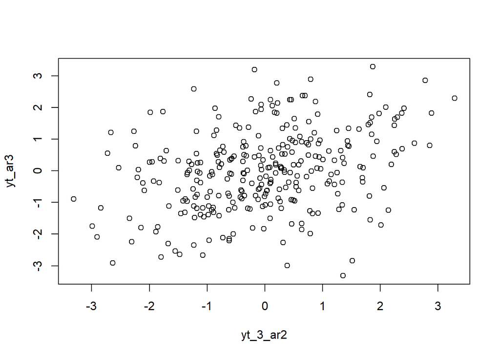

```r
plot(y=yt_ar3,x=yt_3_ar2)
```

Berdasarkan scatterplot tersebut, terlihat bahwa terdapat hubungan positif antara $Y_t$ dengan $Y_t−3$. Hal ini sesuai dengan teori yang ada

```r
cor(yt_ar3,yt_3_ar2)
```

```
## [1] 0.3333544
```

Korelasi antara $Y_t$ dengan $Y_t−3$ dari hasil simulasi mendekati perhitungan teoritis yaitu:

$$\rho_3 = \frac{\phi_1\rho_2+\phi_2\rho1 }{1}
= 0.5(0.5125) + 0.2(0.625)
= 0.38125$$
## Proses ARMA (2,2) ### Pembangkitan Proses ARMA (2,2) ### Manual

```r
arma.sim <- function(n, macoef, arcoef){
  manum <- length(macoef)
  arnum <- length(arcoef)
  stopifnot(manum < n & arnum < n)

  wn <- rnorm(n, sd = 0.5)
  init <- max(manum, arnum)

  arma <- wn[1:init]
  for(i in {init+1}:n){
   mastart <- i - manum
   maend <- i-1
   arstart <- i - arnum
   arend <- i-1
   arma[i] <- sum(arcoef * arma[arstart:arend]) + sum(macoef * wn[mastart:maend])  + wn[i]
   }
  return(arma)
}
```

```r
#contoh untuk ARMA(2,2)
arma22 <- arma.sim(300, c(0.4, 0.6), c(0.5,0.2))

arma22 |> arima(c(2,0,2))
```

```
##
## Call:
## arima(x = arma22, order = c(2, 0, 2))
##
## Coefficients:
##          ar1     ar2     ma1     ma2  intercept
##       0.0894  0.6572  0.6262  0.3456    -0.2189
## s.e.  0.0621  0.0622  0.0721  0.0673     0.2152
##
## sigma^2 estimated as 0.239:  log likelihood = -212.08,  aic = 436.17
```

```r
set.seed(1048)

n <- 300
phi1 <- 0.4
phi2 <- -0.6
theta1 <- 0.5
theta2 <- 0.2

wn <- rnorm(n)

y.arma <- numeric(n)
y.arma[1:2] <- wn[1:2]   # nilai awal biar gak NA

for (i in 3:n) {
  y.arma[i] <- phi1 * y.arma[i-1] +
               phi2 * y.arma[i-2] +
               theta1 * wn[i-1] +
               theta2 * wn[i-2] +
               wn[i]
}

y.arma
```

```
##   [1] -1.059048109  0.401223164  2.104532880  1.841930274 -1.136142520
##   [6] -2.818846316 -1.348784591  0.510123396  0.881370545 -0.650754195
##  [11] -2.214699858 -1.367271171  0.433954814  1.002139920 -0.932775409
##  [16] -1.373378980  0.365238911 -0.762250297 -3.531388350 -1.751656189
##  [21] -1.341903551 -0.635058742 -0.988985122 -0.405684578 -1.471183674
##  [26] -0.179691552  0.223903015 -0.782456221 -1.033744487 -0.964855335
##  [31]  1.327680924  0.631360190 -0.495886163 -1.412353487  0.359376583
##  [36]  1.872933137  1.952589328  0.059766817 -0.978772817  0.438428632
##  [41]  1.813410175 -0.612744086 -2.673119414 -4.180485091 -2.028891256
##  [46]  0.582009605  1.800641609  1.264207660 -0.221114300 -1.696093833
##  [51] -2.183069952  0.222323510  2.079036943  1.566378728 -1.663206258
##  [56] -3.514385786 -3.180370519  0.330948983  2.826372239  0.156351245
##  [61] -0.641023835  0.135646705  0.970665246 -0.216285930 -0.584031412
##  [66]  1.302480207  2.352041202  1.660701831 -1.737621648 -1.555993219
##  [71]  1.231458943  1.101327927 -0.322366693 -1.147560043 -0.952030953
```

[output cut: 45 more lines]

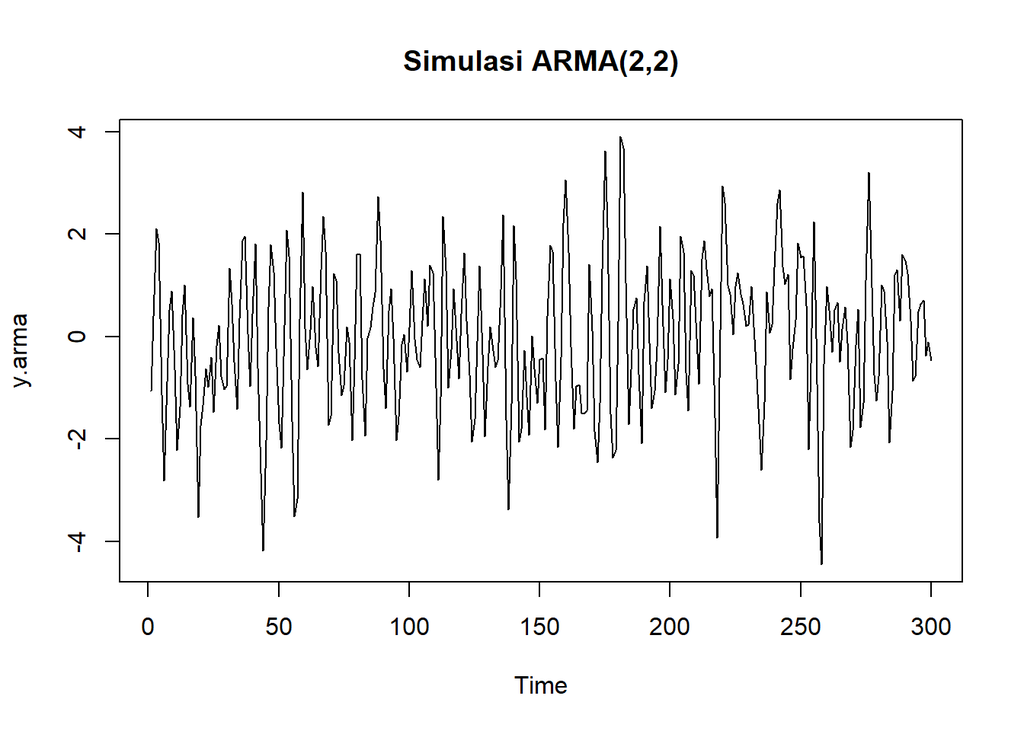

```r
ts.plot(y.arma, main="Simulasi ARMA(2,2)")
```

### arima.sim

```r
arma22 <- arima.sim(
  list(order = c(2,0,2), ar = c(0.5, 0.2), ma = c(0.4, 0.6)),
  n = 300
)
arma22
```

```
## Time Series:
## Start = 1
## End = 300
## Frequency = 1
##   [1]  0.383836735 -0.909604997 -0.988302081 -1.209069843 -2.679807324
##   [6] -3.127627929 -3.782645015 -2.995252900 -0.907976312 -1.494913572
##  [11] -1.111283590 -3.166041849 -2.492577971 -3.838269238 -3.052625029
##  [16] -3.034754946 -3.059765872 -4.504723993 -3.348516978 -3.922376036
##  [21] -2.085164833 -2.571425027 -1.194097101  0.371340526  0.973444019
##  [26]  1.232472983 -1.513188641 -0.506971961 -1.340728814  0.251195409
##  [31] -1.138893709  0.091126806 -0.497668409  1.023892015 -0.356086378
##  [36]  0.656464323 -0.062442202  1.338170944  0.944631213  2.549079067
##  [41]  1.294783938  1.166932443 -0.039599951  0.023034668 -1.079972885
##  [46] -0.373782576 -0.444823684 -0.448347811 -0.540978140 -1.503658572
##  [51] -2.537189065 -1.539366266 -1.957826117 -1.868423201 -2.658222635
```

[output cut: 49 more lines]

## Karakteristik ARMA(2,2)

### Plot Time Series

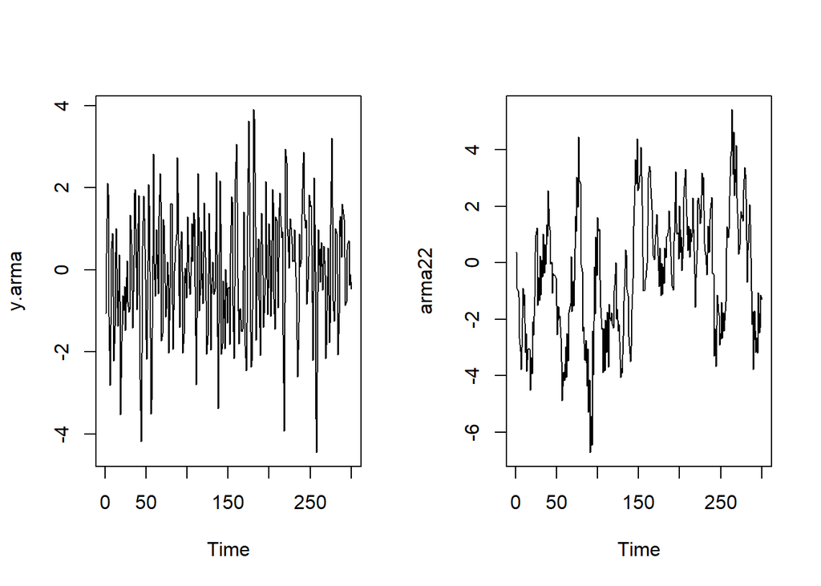

```r
par(mfrow = c(1, 2))
ts.plot(y.arma)
ts.plot(arma22)
```

Berdasarkan plot time series tersebut, terlihat bahwa model ARMA(2,2) cenderung stasioner dalam rataan

### Ploat ACF

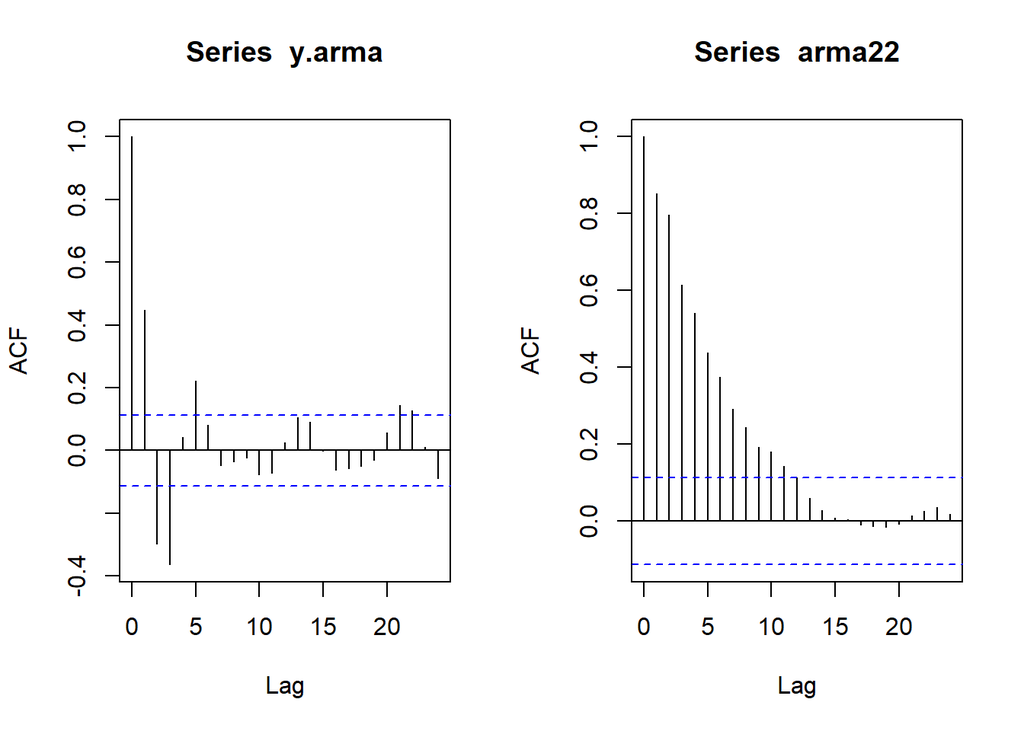

```r
par(mfrow = c(1, 2))
acf(y.arma)
acf(arma22)
```

Berdasarkan plot ACF tersebut, terlihat bahwa model ARMA(2,2) hasil simulasi memiliki plot ACF yang tails off, sesuai dengan teori yang ada.

### Plot PACF

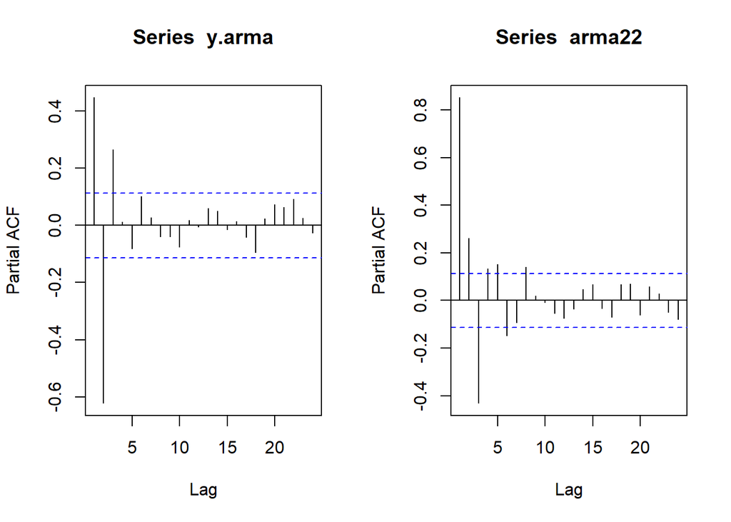

```r
par(mfrow = c(1, 2))
pacf(y.arma)
pacf(arma22)
```

Berdasarkan plot PACF tersebut, terlihat bahwa model ARMA(2,2) hasil simulasi memiliki plot PACF yang tails off, sesuai dengan teori

### Plot EACF

```r
TSA::eacf(y.arma)
```

```
## AR/MA
##   0 1 2 3 4 5 6 7 8 9 10 11 12 13
## 0 x x x o x o o o o o o  o  o  o
## 1 x x x o x o x o o o o  o  o  o
## 2 x x o o x o o o o o o  o  o  o
## 3 o x o o o o o o o o o  o  o  o
## 4 x o x x o o o o o o o  o  o  o
## 5 x x x x x o o o o o o  o  o  o
## 6 x x x x o o o o o o o  o  o  o
## 7 x x o x o o o o o o o  o  o  o
```

## Scatterplot antar lag

### Korelasi antara Yt dengan Yt-1

```r
#Yt
yt_arma <- arma22[-1]
yt_arma
```

```
##   [1] -0.909604997 -0.988302081 -1.209069843 -2.679807324 -3.127627929
##   [6] -3.782645015 -2.995252900 -0.907976312 -1.494913572 -1.111283590
##  [11] -3.166041849 -2.492577971 -3.838269238 -3.052625029 -3.034754946
##  [16] -3.059765872 -4.504723993 -3.348516978 -3.922376036 -2.085164833
##  [21] -2.571425027 -1.194097101  0.371340526  0.973444019  1.232472983
##  [26] -1.513188641 -0.506971961 -1.340728814  0.251195409 -1.138893709
##  [31]  0.091126806 -0.497668409  1.023892015 -0.356086378  0.656464323
##  [36] -0.062442202  1.338170944  0.944631213  2.549079067  1.294783938
##  [41]  1.166932443 -0.039599951  0.023034668 -1.079972885 -0.373782576
##  [46] -0.444823684 -0.448347811 -0.540978140 -1.503658572 -2.537189065
##  [51] -1.539366266 -1.957826117 -1.868423201 -2.658222635 -3.491938699
##  [56] -4.871550614 -3.891971495 -3.860449684 -4.159918209 -2.974883226
##  [61] -4.060763453 -2.490241003 -3.471821268 -1.753710020 -1.663781859
##  [66] -1.430833859  0.235042556 -1.712894253 -0.666986215 -1.526418648
##  [71] -0.620912817  1.656036753  1.108813190  3.034211350  1.968937857
```

[output cut: 45 more lines]

```r
#Yt-1
yt_1_arma <- arma22[-300]
yt_1_arma
```

```
##   [1]  0.383836735 -0.909604997 -0.988302081 -1.209069843 -2.679807324
##   [6] -3.127627929 -3.782645015 -2.995252900 -0.907976312 -1.494913572
##  [11] -1.111283590 -3.166041849 -2.492577971 -3.838269238 -3.052625029
##  [16] -3.034754946 -3.059765872 -4.504723993 -3.348516978 -3.922376036
##  [21] -2.085164833 -2.571425027 -1.194097101  0.371340526  0.973444019
##  [26]  1.232472983 -1.513188641 -0.506971961 -1.340728814  0.251195409
##  [31] -1.138893709  0.091126806 -0.497668409  1.023892015 -0.356086378
##  [36]  0.656464323 -0.062442202  1.338170944  0.944631213  2.549079067
##  [41]  1.294783938  1.166932443 -0.039599951  0.023034668 -1.079972885
##  [46] -0.373782576 -0.444823684 -0.448347811 -0.540978140 -1.503658572
##  [51] -2.537189065 -1.539366266 -1.957826117 -1.868423201 -2.658222635
##  [56] -3.491938699 -4.871550614 -3.891971495 -3.860449684 -4.159918209
##  [61] -2.974883226 -4.060763453 -2.490241003 -3.471821268 -1.753710020
##  [66] -1.663781859 -1.430833859  0.235042556 -1.712894253 -0.666986215
##  [71] -1.526418648 -0.620912817  1.656036753  1.108813190  3.034211350
```

[output cut: 45 more lines]

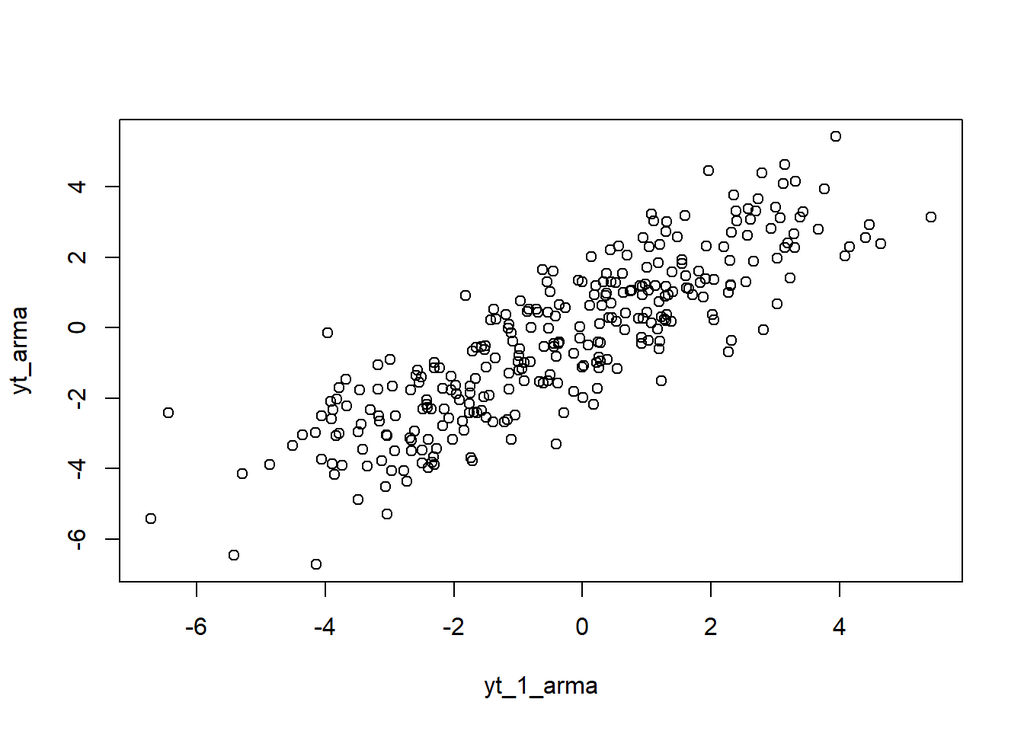

```r
plot(y=yt_arma,x=yt_1_arma)
```

Berdasarkan scatterplot tersebut, terlihat bahwa terdapat hubungan positif antara $Y_t$ dengan $Y_t−1$. Hal ini sesuai dengan teori yang ada.

```r
cor(yt_arma,yt_1_arma)
```

```
## [1] 0.8520988
```

$$\gamma_1 = (\theta_1 + \theta_1\theta_2 + \phi_1 +
\phi_1\theta_1)\sigma^2
+ \phi_2
\gamma_0=(0.4+0.4(0.6)+0.5+0.5(0.4))\sigma^2+0.2(1.92\sigma^2)=1.724\sigma^2$$

$$\gamma_2 = \theta_2 \sigma^2 + \phi_1 \gamma_1 + \phi_2
\gamma_0=0.6\sigma^2+0.5(1.724\sigma^2)+0.2(1.92\sigma^2)=1.846\sigma^2$$

$$\gamma_3 = \phi_1 \gamma_2 + \phi_2
\gamma_1=0.5(1.846\sigma^2)+0.2(1.724\sigma^2)=1.2678\sigma^2$$

Sehingga autokorelasi:
$$\rho_1 = \frac{\gamma_1}{\gamma_0}=\frac{1.724\sigma^2}{1.92\sigma^2}=
0.8979$$
### Korelasi antara Yt dengan Yt-2

```r
#Yt
yt_arma2 <- arma22[-c(1,2)]
yt_arma2
```

```
##   [1] -0.988302081 -1.209069843 -2.679807324 -3.127627929 -3.782645015
##   [6] -2.995252900 -0.907976312 -1.494913572 -1.111283590 -3.166041849
##  [11] -2.492577971 -3.838269238 -3.052625029 -3.034754946 -3.059765872
##  [16] -4.504723993 -3.348516978 -3.922376036 -2.085164833 -2.571425027
##  [21] -1.194097101  0.371340526  0.973444019  1.232472983 -1.513188641
##  [26] -0.506971961 -1.340728814  0.251195409 -1.138893709  0.091126806
##  [31] -0.497668409  1.023892015 -0.356086378  0.656464323 -0.062442202
##  [36]  1.338170944  0.944631213  2.549079067  1.294783938  1.166932443
##  [41] -0.039599951  0.023034668 -1.079972885 -0.373782576 -0.444823684
##  [46] -0.448347811 -0.540978140 -1.503658572 -2.537189065 -1.539366266
##  [51] -1.957826117 -1.868423201 -2.658222635 -3.491938699 -4.871550614
##  [56] -3.891971495 -3.860449684 -4.159918209 -2.974883226 -4.060763453
##  [61] -2.490241003 -3.471821268 -1.753710020 -1.663781859 -1.430833859
##  [66]  0.235042556 -1.712894253 -0.666986215 -1.526418648 -0.620912817
##  [71]  1.656036753  1.108813190  3.034211350  1.968937857  4.471130099
```

[output cut: 45 more lines]

```r
#Yt-1
yt_1_arma2 <- arma22[-c(299,300)]
yt_1_arma2
```

```
##   [1]  0.383836735 -0.909604997 -0.988302081 -1.209069843 -2.679807324
##   [6] -3.127627929 -3.782645015 -2.995252900 -0.907976312 -1.494913572
##  [11] -1.111283590 -3.166041849 -2.492577971 -3.838269238 -3.052625029
##  [16] -3.034754946 -3.059765872 -4.504723993 -3.348516978 -3.922376036
##  [21] -2.085164833 -2.571425027 -1.194097101  0.371340526  0.973444019
##  [26]  1.232472983 -1.513188641 -0.506971961 -1.340728814  0.251195409
##  [31] -1.138893709  0.091126806 -0.497668409  1.023892015 -0.356086378
##  [36]  0.656464323 -0.062442202  1.338170944  0.944631213  2.549079067
##  [41]  1.294783938  1.166932443 -0.039599951  0.023034668 -1.079972885
##  [46] -0.373782576 -0.444823684 -0.448347811 -0.540978140 -1.503658572
##  [51] -2.537189065 -1.539366266 -1.957826117 -1.868423201 -2.658222635
##  [56] -3.491938699 -4.871550614 -3.891971495 -3.860449684 -4.159918209
##  [61] -2.974883226 -4.060763453 -2.490241003 -3.471821268 -1.753710020
##  [66] -1.663781859 -1.430833859  0.235042556 -1.712894253 -0.666986215
##  [71] -1.526418648 -0.620912817  1.656036753  1.108813190  3.034211350
```

[output cut: 45 more lines]

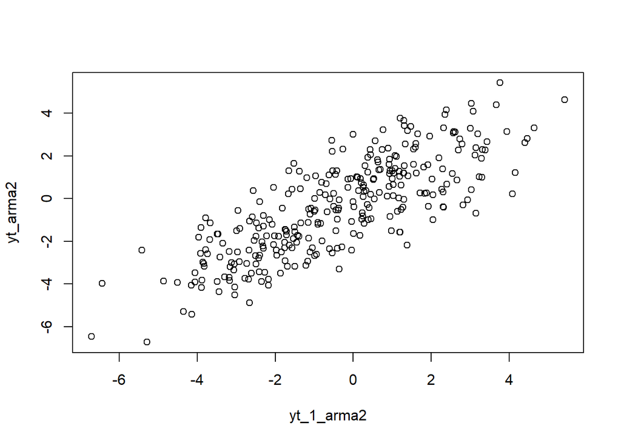

```r
plot(y=yt_arma2,x=yt_1_arma2)
```

```r
cor(yt_arma2,yt_1_arma2)
```

```
## [1] 0.7977534
```

$$\rho_2 = \frac{\gamma_2}{\gamma_0} =
\frac{1.846\sigma^2}{1.92\sigma^2}=0.9614$$
### Korelasi antara Yt dengan Yt-3

```r
#Yt
yt_arma3 <- arma22[-c(1,2,3)]
yt_arma3
```

```
##   [1] -1.209069843 -2.679807324 -3.127627929 -3.782645015 -2.995252900
##   [6] -0.907976312 -1.494913572 -1.111283590 -3.166041849 -2.492577971
##  [11] -3.838269238 -3.052625029 -3.034754946 -3.059765872 -4.504723993
##  [16] -3.348516978 -3.922376036 -2.085164833 -2.571425027 -1.194097101
##  [21]  0.371340526  0.973444019  1.232472983 -1.513188641 -0.506971961
##  [26] -1.340728814  0.251195409 -1.138893709  0.091126806 -0.497668409
##  [31]  1.023892015 -0.356086378  0.656464323 -0.062442202  1.338170944
##  [36]  0.944631213  2.549079067  1.294783938  1.166932443 -0.039599951
##  [41]  0.023034668 -1.079972885 -0.373782576 -0.444823684 -0.448347811
##  [46] -0.540978140 -1.503658572 -2.537189065 -1.539366266 -1.957826117
##  [51] -1.868423201 -2.658222635 -3.491938699 -4.871550614 -3.891971495
##  [56] -3.860449684 -4.159918209 -2.974883226 -4.060763453 -2.490241003
##  [61] -3.471821268 -1.753710020 -1.663781859 -1.430833859  0.235042556
##  [66] -1.712894253 -0.666986215 -1.526418648 -0.620912817  1.656036753
##  [71]  1.108813190  3.034211350  1.968937857  4.471130099  2.935892719
```

[output cut: 45 more lines]

```r
#Yt-1
yt_1_arma3 <- arma22[-c(298,299,300)]
yt_1_arma3
```

```
##   [1]  0.383836735 -0.909604997 -0.988302081 -1.209069843 -2.679807324
##   [6] -3.127627929 -3.782645015 -2.995252900 -0.907976312 -1.494913572
##  [11] -1.111283590 -3.166041849 -2.492577971 -3.838269238 -3.052625029
##  [16] -3.034754946 -3.059765872 -4.504723993 -3.348516978 -3.922376036
##  [21] -2.085164833 -2.571425027 -1.194097101  0.371340526  0.973444019
##  [26]  1.232472983 -1.513188641 -0.506971961 -1.340728814  0.251195409
##  [31] -1.138893709  0.091126806 -0.497668409  1.023892015 -0.356086378
##  [36]  0.656464323 -0.062442202  1.338170944  0.944631213  2.549079067
##  [41]  1.294783938  1.166932443 -0.039599951  0.023034668 -1.079972885
##  [46] -0.373782576 -0.444823684 -0.448347811 -0.540978140 -1.503658572
##  [51] -2.537189065 -1.539366266 -1.957826117 -1.868423201 -2.658222635
##  [56] -3.491938699 -4.871550614 -3.891971495 -3.860449684 -4.159918209
##  [61] -2.974883226 -4.060763453 -2.490241003 -3.471821268 -1.753710020
##  [66] -1.663781859 -1.430833859  0.235042556 -1.712894253 -0.666986215
##  [71] -1.526418648 -0.620912817  1.656036753  1.108813190  3.034211350
```

[output cut: 45 more lines]

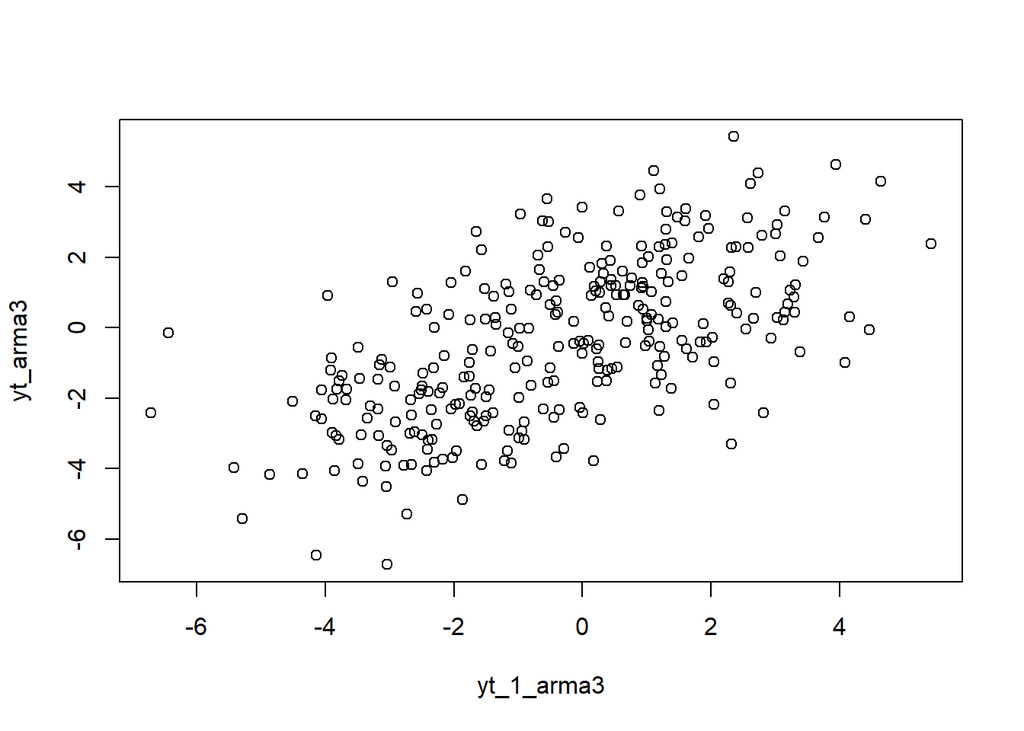

```r
plot(y=yt_arma3,x=yt_1_arma3)
```

```r
cor(yt_arma3,yt_1_arma3)
```

```
## [1] 0.6150706
```

$$\rho_3 =
\frac{\gamma_3}{\gamma_0}=\frac{1.2678\sigma^2}{1.92\sigma^2}=0,66$$